# 1주차 팀프로젝트

1. 프로젝트 주제
   - 러시아·우크라이나 전쟁이 한국 경제에 미친 영향 분석
     - 러·우 전쟁이후 한국 수출입 동향 분석
1. 자료 출처
   - 수출입 품목 데이터 (2021.05~ 2022.06)
     - 수출입무역통계 홈페이지 : https://unipass.customs.go.kr/ets/index.do?menuId=ETS_MNU_00000103
   - 기사 참조:
     - 한경닷컴(박상용기자) : https://www.hankyung.com/international/article/2022040182971
     - 한경닷컴(강경민/고윤상 기자) : https://www.hankyung.com/economy/article/2022030830531
1. 프로젝트 내용 :
   - 국내 수출입 데이터 분석
   - 10대 수출입 품목 분석
   - 한러 10대 수출입 품목 분석
   - 국내 주 수입 원재료 분석

```python
# 모듈 로딩 ----------------------------------------------------------
import matplotlib.pyplot as plt
import matplotlib.font_manager as fm
import matplotlib
import platform
import matplotlib.ticker as mticker
from datetime import datetime
import time
import warnings
import pandas as pd
from pandas.core.common import SettingWithCopyWarning

# 그래프 폰트설정
if platform.system() == 'Windows':
    #font_name = fm.FontProperties(fname="c:\Windows\Fonts\malgun.ttf").get_name()
    plt.rc('font', family='Malgun Gothic')
else:
    plt.rc('font', family='AppleGothic')

# 음수 부호 깨짐 방지
matplotlib.rcParams['axes.unicode_minus'] = False

# settingWarnings ignore
warnings.simplefilter(action="ignore", category=SettingWithCopyWarning)
```

```python
# 파일 불러오기 -----------------------------------------------------------
DIR = './data/'
FILE = DIR + '수출입총괄.xls'
FILE2 = DIR + '10대수출2021.xls'
FILE3 = DIR + '10대수출2022.xls'
FILE4 = DIR + '10대수입2021.xls'
FILE5 = DIR + '10대수입2022.xls'
FILE6 = DIR + '나프타 수입.xls'
FILE7 = DIR + '니켈 수입1.xls'
FILE8 = DIR + '금리.csv'
```

### 3-1. 국내 총 수출입 데이터 분석

```python
# 파일 읽기 --------------------------------------------------------------
tradeDF = pd.read_excel(FILE, header=4)
print(tradeDF.info())
tradeDF
```

```
<class 'pandas.core.frame.DataFrame'>
RangeIndex: 15 entries, 0 to 14
Data columns (total 6 columns):
 #   Column  Non-Null Count  Dtype
---  ------  --------------  -----
 0   기간      15 non-null     object
 1   수출건수    15 non-null     object
 2   수출금액    15 non-null     object
 3   수입건수    15 non-null     object
 4   수입금액    15 non-null     object
 5   무역수지    15 non-null     object
dtypes: object(6)
memory usage: 848.0+ bytes
None
```

|  | 기간 | 수출건수 | 수출금액 | 수입건수 | 수입금액 | 무역수지 |
| --- | --- | --- | --- | --- | --- | --- |
| 0 | 총계 | 17,319,028 | 797,224,742 | 46,607,987 | 788,409,453 | 8,815,289 |
| 1 | 2021.05 | 1,143,835 | 50,725,161 | 3,245,257 | 47,910,522 | 2,814,640 |
| 2 | 2021.06 | 1,513,595 | 54,778,905 | 3,101,662 | 50,429,027 | 4,349,878 |
| 3 | 2021.07 | 1,182,251 | 55,461,518 | 3,225,209 | 53,676,256 | 1,785,262 |
| 4 | 2021.08 | 1,122,015 | 53,165,104 | 3,180,345 | 51,581,093 | 1,584,011 |
| 5 | 2021.09 | 1,502,399 | 55,913,862 | 3,199,940 | 51,636,341 | 4,277,521 |
| 6 | 2021.10 | 1,104,157 | 55,660,373 | 3,356,096 | 53,847,824 | 1,812,548 |
| 7 | 2021.11 | 1,535,829 | 60,330,542 | 3,418,506 | 57,357,549 | 2,972,993 |
| 8 | 2021.12 | 1,322,594 | 60,734,117 | 3,657,650 | 61,159,671 | -425,554 |
| 9 | 2022.01 | 1,099,933 | 55,460,865 | 3,434,133 | 60,363,481 | -4,902,616 |
| 10 | 2022.02 | 1,017,808 | 54,154,313 | 3,131,844 | 53,133,762 | 1,020,551 |
| 11 | 2022.03 | 1,403,100 | 63,785,078 | 3,543,899 | 63,593,038 | 192,041 |
| 12 | 2022.04 | 1,027,251 | 57,849,157 | 3,398,513 | 60,326,206 | -2,477,049 |
| 13 | 2022.05 | 1,100,940 | 61,579,891 | 3,365,897 | 63,194,249 | -1,614,358 |
| 14 | 2022.06 | 1,243,321 | 57,625,856 | 3,349,036 | 60,200,435 | -2,574,579 |

```python
# 분석 칼럼별 데이터 저장 -----------------------------------------------------
trade_balance = tradeDF.iloc[1:,[0,5]]
trade_balance = trade_balance.set_index('기간')
trade_balance.head(2)
```

| 기간 | 무역수지 |
| --- | --- |
| 2021.05 | 2,814,640 |
| 2021.06 | 4,349,878 |

```python
# 데이터 전처리 -------------------------------------------------------------
# (1) 콤마 제거, dtype object ==> int64 변경
trade_balance['무역수지']=trade_balance.무역수지.str.replace(',', '').astype('int64')
trade_balance.info()
```

```
<class 'pandas.core.frame.DataFrame'>
Index: 14 entries, 2021.05 to 2022.06
Data columns (total 1 columns):
 #   Column  Non-Null Count  Dtype
---  ------  --------------  -----
 0   무역수지    14 non-null     int64
dtypes: int64(1)
memory usage: 224.0+ bytes
```

```python
# (2) 인덱스 설정
numDF = tradeDF.iloc[1:,[0,1,3]]
numDF=numDF.set_index('기간')
numDF.head()
```

| 기간 | 수출건수 | 수입건수 |
| --- | --- | --- |
| 2021.05 | 1,143,835 | 3,245,257 |
| 2021.06 | 1,513,595 | 3,101,662 |
| 2021.07 | 1,182,251 | 3,225,209 |
| 2021.08 | 1,122,015 | 3,180,345 |
| 2021.09 | 1,502,399 | 3,199,940 |

```python
numDF['수출건수']=numDF.수출건수.str.replace(',', '').astype('int64')
numDF['수입건수']=numDF.수입건수.str.replace(',', '').astype('int64')
```

```python
numDF.info()
```

```
<class 'pandas.core.frame.DataFrame'>
Index: 14 entries, 2021.05 to 2022.06
Data columns (total 2 columns):
 #   Column  Non-Null Count  Dtype
---  ------  --------------  -----
 0   수출건수    14 non-null     int64
 1   수입건수    14 non-null     int64
dtypes: int64(2)
memory usage: 336.0+ bytes
```

```python
priceDF = tradeDF.iloc[1:, [0,2,4]]
priceDF=priceDF.set_index('기간')
priceDF.info()
```

```
<class 'pandas.core.frame.DataFrame'>
Index: 14 entries, 2021.05 to 2022.06
Data columns (total 2 columns):
 #   Column  Non-Null Count  Dtype
---  ------  --------------  -----
 0   수출금액    14 non-null     object
 1   수입금액    14 non-null     object
dtypes: object(2)
memory usage: 336.0+ bytes
```

```python
priceDF['수출금액']=priceDF.수출금액.str.replace(',', '').astype('int64')
priceDF['수입금액']=priceDF.수입금액.str.replace(',', '').astype('int64')
priceDF.info()
```

```
<class 'pandas.core.frame.DataFrame'>
Index: 14 entries, 2021.05 to 2022.06
Data columns (total 2 columns):
 #   Column  Non-Null Count  Dtype
---  ------  --------------  -----
 0   수출금액    14 non-null     int64
 1   수입금액    14 non-null     int64
dtypes: int64(2)
memory usage: 336.0+ bytes
```

```python
# 수출건수, 수출금액별 최고, 최저값 도출 -----------------------------------------------
idx_max_num = numDF.idxmax()
max_num = numDF.max()
idx_min_num = numDF.idxmin()
min_num = numDF.min()
print('최고 수출건수 : {}월 {:,}건 / 최고 수입건수 : {}월 {:,}건'.format(idx_max_num[0], max_num[0], idx_max_num[1], max_num[1]))
print('최저 수출건수 : {}월 {:,}건 / 최저 수입건수 : {}월 {:,}건'.format(idx_min_num[0], min_num[0], idx_min_num[1], min_num[1]))
```

```
최고 수출건수 : 2021.11월 1,535,829건 / 최고 수입건수 : 2021.12월 3,657,650건
최저 수출건수 : 2022.02월 1,017,808건 / 최저 수입건수 : 2021.06월 3,101,662건
```

```python
idx_max_price = priceDF.idxmax()
max_price = priceDF.max()
idx_minx_price = priceDF.idxmin()
min_price = priceDF.min()
print('최고 수출금액 : {}월 {:,}건 / 최고 수입금액 : {}월 {:,}건'.format(idx_max_price[0], max_price[0], idx_max_price[1], max_price[1]))
print('최저 수출금액 : {}월 {:,}건 / 최저 수입금액 : {}월 {:,}건'.format(idx_minx_price[0], min_price[0], idx_minx_price[1], min_price[1]))
```

```
최고 수출금액 : 2022.03월 63,785,078건 / 최고 수입금액 : 2022.03월 63,593,038건
최저 수출금액 : 2021.05월 50,725,161건 / 최저 수입금액 : 2021.05월 47,910,522건
```

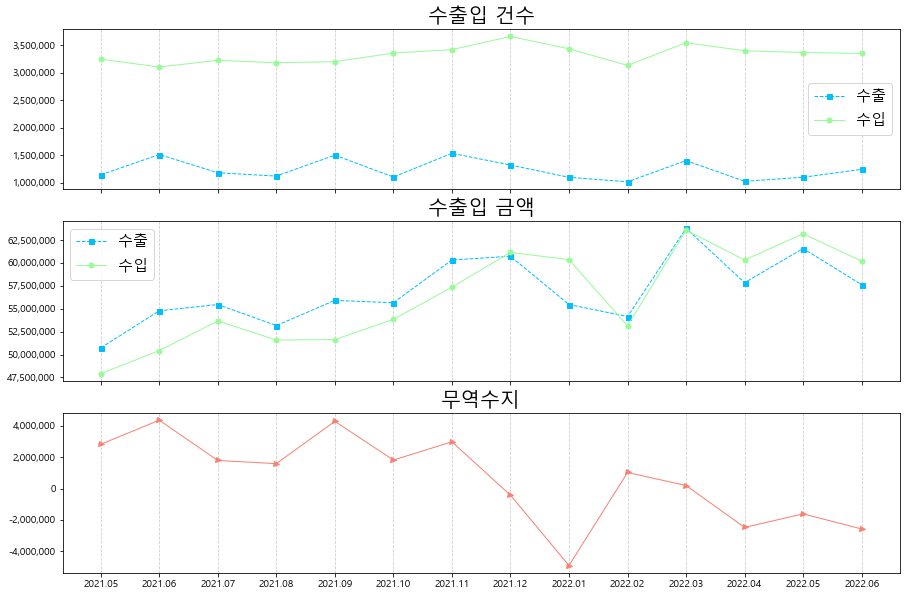

```python
# 수출 총괄 그래프 도출 ----------------------------------------------------------------
fig, axes = plt.subplots(3, 1, figsize=(15,10), sharex=True)

# fig.suptitle('한국 수출입 총괄', fontsize = 25)
color = ['salmon','gold','darkorange','deepskyblue','palegreen', 'gray', 'silver']
label = ['수출','수입']

plt.subplot(3,1,1)
plt.title('수출입 건수', fontsize=20)
plt.plot(numDF.iloc[:,0], label=label[0], color=color[3], marker='s', markersize=5, linestyle='--', linewidth=1.0)
plt.plot(numDF.iloc[:,1], label=label[1], color=color[4], marker='o', markersize=5, linestyle='-', linewidth=1.0)
plt.grid(True, axis='x', color='silver', alpha=0.8, linestyle='--')
plt.legend(fontsize=15, loc=0)
current_values = plt.gca().get_yticks()
plt.gca().set_yticklabels(['{:,.0f}'.format(x) for x in current_values])


plt.subplot(3,1,2)
plt.title('수출입 금액', fontsize=20)
plt.plot(priceDF.iloc[:,0], label=label[0], color=color[3], marker='s', markersize=5, linestyle='--', linewidth=1.0)
plt.plot(priceDF.iloc[:,1], label=label[1], color=color[4], marker='o', markersize=5, linestyle='-', linewidth=1.0)
plt.grid(True, axis='x', color='silver', alpha=0.8, linestyle='--')
plt.legend(fontsize=15)
current_values = plt.gca().get_yticks()
plt.gca().set_yticklabels(['{:,.0f}'.format(x) for x in current_values])

plt.subplot(3,1,3)
plt.title('무역수지', fontsize=20)
plt.plot(trade_balance, marker='>', color = color[0] ,markersize=5, linestyle='-', linewidth=1.0)
plt.grid(True, axis='x', color='silver', alpha=0.8, linestyle='--')
current_values = plt.gca().get_yticks()
plt.gca().set_yticklabels(['{:,.0f}'.format(x) for x in current_values])

plt.show()
```

#### [국내 수출입 데이터 분석]

21년 대비 22년의 수출입 건수의 변동폭이 크지 않음에도 불구하고 올 상반기부터 지속된 원재료, 원유, 에너지, 곡물 등의 가격상승으로 인해 수출입금액 변동폭이 커져 무역수지 또한 지속적인 하락세를 보이는 것으로 나타났다. 올해 1분기(1~3월) 국제 원자재 가격 상승세가 32년 만에 최대 수준을 기록한 것으로 나타났다. 무역수지 하락의 원인으로는 2022년 상반기 러시아와 우크라이나 전쟁 발발을 꼽을 수 있다. 전쟁 발발 초기인 22년 1월에 무역수지가 급하락한 것으로 보아 러시아와 우크라이나 전쟁이 한국 수출입에 큰 영향을 준 것을 알 수 있다. 일각에서는 우크라이나 남쪽의 흑해 항로를 거쳐 세계로 수출되던 원자재 공급이 차질을 빚으면서 극심한 가격 변동이 발생했다는 분석이 나온다.

그로인해 원자재 시장에는 빠른 속도로 투자금이 몰리고 있다. 금융정보 제공업체 리피니티브리퍼에 따르면 원자재에 투자하는 뮤추얼펀드 및 상장지수펀드(ETF)에는 12주째 자금이 순유입되고 있다. 원자재 현물 가격이 선물 가격보다 높은 현상인 ‘백워데이션’이 뚜렷하다는 점도 주목받고 있다. 이는 당장 시장에 필요한 원자재 공급이 부족하다는 의미로 해석된다. 당분간 원자재 공급이 부족할 수 있다는 뜻이어서 원자재 가격이 추가 상승할 것이란 기대가 커지고 있다.

### 3-2. 국내 10대 주요품목 수출입 데이터 분석

```python
out_DF1 = pd.read_excel(FILE2, header=4)
out_DF2 = pd.read_excel(FILE3, header=4)
in_DF1 = pd.read_excel(FILE4, header=4)
in_DF2 = pd.read_excel(FILE5, header=4)
in_DF2.head()
```

|  | 기간 | 품목명 | HS코드 | 수출중량 | 수출금액 | 무역수지 |
| --- | --- | --- | --- | --- | --- | --- |
| 0 | 2022 | 전기기기와 그 부분품, 녹음기ㆍ음성 재생기ㆍ텔레비전의 영상과 음성의 기록기ㆍ재생기와... | 85 | 976,830,053 | 62,765,839 | 46,718,125 |
| 1 | 2022 | 원자로ㆍ보일러ㆍ기계류와 이들의 부분품 | 84 | 1,289,954,601 | 35,098,375 | 3,182,048 |
| 2 | 2022 | 철도용이나 궤도용 외의 차량과 그 부분품ㆍ부속품 | 87 | 594,959,203 | 10,202,633 | 24,879,716 |
| 3 | 2022 | 플라스틱과 그 제품 | 39 | 1,392,436,281 | 7,298,446 | 15,793,159 |
| 4 | 2022 | 광물성 연료ㆍ광물유(鑛物油)와 이들의 증류물, 역청(瀝靑)물질, 광물성 왁스 | 27 | 172,921,500,257 | 102,690,974 | -71,339,572 |

```python
# 연도별 수출금액 카테고리만 추출
outDF1 = out_DF1.iloc[:,[1,3,4]]
outDF2 = out_DF2.iloc[:,[1,3,4]]
inDF1 = in_DF1.iloc[:,[1,3,4]]
inDF2 = in_DF2.iloc[:,[1,3,4]]
inDF2.info()
inDF2.head()
```

```
<class 'pandas.core.frame.DataFrame'>
RangeIndex: 10 entries, 0 to 9
Data columns (total 3 columns):
 #   Column  Non-Null Count  Dtype
---  ------  --------------  -----
 0   품목명     10 non-null     object
 1   수출중량    10 non-null     object
 2   수출금액    10 non-null     object
dtypes: object(3)
memory usage: 368.0+ bytes
```

|  | 품목명 | 수출중량 | 수출금액 |
| --- | --- | --- | --- |
| 0 | 전기기기와 그 부분품, 녹음기ㆍ음성 재생기ㆍ텔레비전의 영상과 음성의 기록기ㆍ재생기와... | 976,830,053 | 62,765,839 |
| 1 | 원자로ㆍ보일러ㆍ기계류와 이들의 부분품 | 1,289,954,601 | 35,098,375 |
| 2 | 철도용이나 궤도용 외의 차량과 그 부분품ㆍ부속품 | 594,959,203 | 10,202,633 |
| 3 | 플라스틱과 그 제품 | 1,392,436,281 | 7,298,446 |
| 4 | 광물성 연료ㆍ광물유(鑛物油)와 이들의 증류물, 역청(瀝靑)물질, 광물성 왁스 | 172,921,500,257 | 102,690,974 |

```python
# 데이터 전처리 ------------------------------------------------------------------
# (1)object안의 왼쪽 공백 지워줌

outDF1['수출금액']=outDF1['수출금액'].str.lstrip()
outDF1['수출중량']=outDF1['수출중량'].str.lstrip()
outDF2['수출금액']=outDF2['수출금액'].str.lstrip()
outDF2['수출중량']=outDF2['수출중량'].str.lstrip()
inDF1['수출금액']=inDF1['수출금액'].str.lstrip()
inDF1['수출중량']=inDF1['수출중량'].str.lstrip()
inDF2['수출금액']=inDF2['수출금액'].str.lstrip()
inDF2['수출중량']=inDF2['수출중량'].str.lstrip()
```

```python
# (2)콤마제거 및 dtype : object ==> int64 변경
outDF1['수출금액'] = outDF1.수출금액.str.replace(',','').astype('int64')
outDF1['수출중량'] = outDF1.수출중량.str.replace(',','').astype('int64')

outDF2['수출금액'] = outDF2.수출금액.str.replace(',','').astype('int64')
outDF2['수출중량'] = outDF2.수출중량.str.replace(',','').astype('int64')

inDF1['수출금액'] = inDF1.수출금액.str.replace(',','').astype('int64')
inDF1['수출중량'] = inDF1.수출중량.str.replace(',','').astype('int64')

inDF2['수출금액'] = inDF2.수출금액.str.replace(',','').astype('int64')
inDF2['수출중량'] = inDF2.수출중량.str.replace(',','').astype('int64')
```

```python
# (3) 2021, 2022년 자료 병합
outDF1['2022년 수출액'] = outDF2['수출금액']
outDF1['2022년 수출중량'] = outDF2['수출중량']

outDF1.rename(columns={'수출금액':'2021년 수출액'}, inplace=True)
outDF1.rename(columns={'수출중량':'2021년 수출중량'}, inplace=True)

inDF1['2022년 수입액'] = inDF2['수출금액']
inDF1['2022년 수입중량'] = inDF2['수출중량']

inDF1.rename(columns={'수출금액':'2021년 수입액'}, inplace=True)
inDF1.rename(columns={'수출중량':'2021년 수입중량'}, inplace=True)
```

```python
outDF1.set_index('품목명', inplace=True)
inDF1.set_index('품목명', inplace=True)
outDF1.index=['전자기기ㆍ음성관련기기 및 부품', '원자로ㆍ보일러ㆍ기계류와 부품', '철도ㆍ차량 및 부품','플라스틱',
              '광물성연료','철강','유기화학품','광학기기ㆍ촬영관련기기ㆍ의료용 기기 및 부품','선박 및 수상 구조물','철강제품']
inDF1.index=['전자기기ㆍ음성관련기기 및 부품', '원자로ㆍ보일러ㆍ기계류와 부품', '철도ㆍ차량 및 부품','플라스틱',
              '광물성연료','철강','유기화학품','광학기기ㆍ촬영관련기기ㆍ의료용 기기 및 부품','유무기화학품ㆍ귀금속ㆍ방사성원소','광ㆍ슬래그ㆍ회']
```

```python
inDF1
```

|  | 2021년 수입중량 | 2021년 수입액 | 2022년 수입액 | 2022년 수입중량 |
| --- | --- | --- | --- | --- |
| 전자기기ㆍ음성관련기기 및 부품 | 1886936987 | 114802749 | 62765839 | 976830053 |
| 원자로ㆍ보일러ㆍ기계류와 부품 | 2570787095 | 69100411 | 35098375 | 1289954601 |
| 철도ㆍ차량 및 부품 | 1149475979 | 20017428 | 10202633 | 594959203 |
| 플라스틱 | 2979304249 | 14175956 | 7298446 | 1392436281 |
| 광물성연료 | 349999211075 | 137572591 | 102690974 | 172921500257 |
| 철강 | 19720814859 | 18494427 | 10785532 | 10648543302 |
| 유기화학품 | 8271433807 | 15973899 | 8902210 | 4173681413 |
| 광학기기ㆍ촬영관련기기ㆍ의료용 기기 및 부품 | 213693698 | 22497976 | 11179678 | 107781655 |
| 유무기화학품ㆍ귀금속ㆍ방사성원소 | 4816098697 | 11024503 | 9116055 | 2229927582 |
| 광ㆍ슬래그ㆍ회 | 85499714343 | 24588155 | 11741056 | 39649235465 |

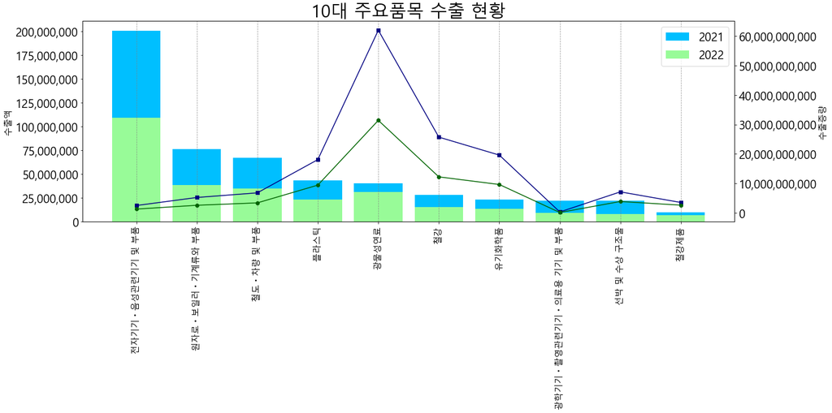

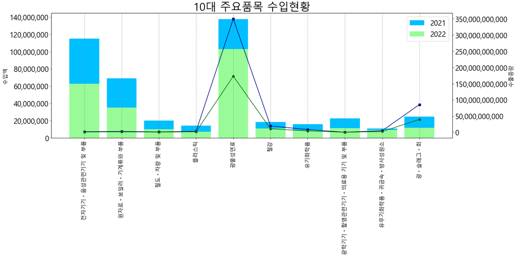

```python
fig, ax1 = plt.subplots(figsize=(20,10))
plt.xticks(rotation=90, fontsize=15)
label = ['2021','2022']


plt.title('10대 주요품목 수출 현황', fontsize=30)
plt.ylabel('수출액', fontsize=15)
plt.bar(outDF1.index,outDF1['2021년 수출액'], color=color[3], label=label[0])
plt.bar(outDF1.index,outDF1['2022년 수출액'], color=color[4], label=label[1])
plt.yticks(fontsize=20)
plt.legend(fontsize=20)
plt.grid(True, axis='x', color='gray', alpha=0.8, linestyle='--')

current_values = plt.gca().get_yticks()
plt.gca().set_yticklabels(['{:,.0f}'.format(x) for x in current_values])

# for i in range(len(outDF1.index)):
#     plt.text(outDF1.index[i], outDF1['2021년 수출액'][i] / 4, str(outDF1['2021년 수출액'][i]),
#             fontsize = 15, horizontalalignment='center', color = 'w')

#     plt.text(outDF1.index[i], (outDF1['2021년 수출액'][i] + outDF1['2021년 수출액'][i] + outDF1['2022년 수출액'][i])
#              / 4, str(outDF1['2022년 수출액'][i]),
#             fontsize = 15, horizontalalignment='center', color = 'b')

ax2 = ax1.twinx()
ax2.set_ylabel('수출증량', fontsize=15)
ax2.plot(outDF1.index, outDF1['2021년 수출중량'], marker='s', color='navy')
ax2.plot(outDF1.index, outDF1['2022년 수출중량'], marker='o', color='darkgreen')
ax2.tick_params(axis='y')
plt.yticks(fontsize=20)


current_values = plt.gca().get_yticks()
plt.gca().set_yticklabels(['{:,.0f}'.format(x) for x in current_values])

fig.tight_layout()

fig, ax1 = plt.subplots(figsize=(20,10))
plt.xticks(rotation=90, fontsize=15)
label = ['2021','2022']

plt.title('10대 주요품목 수입현황', fontsize=30)
plt.ylabel('수입액', fontsize=15)
plt.bar(inDF1.index,inDF1['2021년 수입액'], color=color[3], label=label[0])
plt.bar(inDF1.index,inDF1['2022년 수입액'], color=color[4], label=label[1])
plt.yticks(fontsize=20)
plt.legend(fontsize=20)
plt.grid(True, axis='x', color='gray', alpha=0.8, linestyle='--')

current_values = plt.gca().get_yticks()
plt.gca().set_yticklabels(['{:,.0f}'.format(x) for x in current_values])

# for i in range(len(inDF1.index)):
#     plt.text(inDF1.index[i], inDF1['2021년 수입액'][i] / 4, str(inDF1['2021년 수입액'][i]),
#             fontsize = 15, horizontalalignment='center', color = 'w')

#     plt.text(inDF1.index[i], (inDF1['2021년 수입액'][i] + inDF1['2021년 수입액'][i] + inDF1['2022년 수입액'][i])
#              / 4, str(inDF1['2022년 수입액'][i]),
#             fontsize = 15, horizontalalignment='center', color = 'b')

ax2 = ax1.twinx()
ax2.set_ylabel('수출증량', fontsize=15)
ax2.plot(inDF1.index, inDF1['2021년 수입중량'], marker='s', color='navy')
ax2.plot(inDF1.index, inDF1['2022년 수입중량'], marker='o', color='darkgreen')
ax2.tick_params(axis='y')
plt.yticks(fontsize=20)

current_values = plt.gca().get_yticks()
plt.gca().set_yticklabels(['{:,.0f}'.format(x) for x in current_values])

fig.tight_layout()


plt.show()
```

#### [10대 주요 수출입 품목 데이터 분석]

10대 주요 수출 현황을 살펴보면 전반적으로 수출이 감소한 것으로 보이나 2022년은 상반기 자료만 반영하였으므로 건수를 비교하면 지난해와 거의 비슷하다 볼 수 있다. 광물성원료의 수출액은 수출건수 대비 전년도에 비해 상반기 자료임에도 불구 작년 수출액과 금액이 비슷한 것을 볼 수 있다. 국내 수출 원자재가격의 급등으로 그에따른 에너지, 광업이 새로운 수혜 업종으로 떠오를 것으로 예측된다.

에프앤가이드 조사에서도 SK이노베이션은 한 달 전에 비해 1분기 영업이익 전망치가 5755억원에서 5979억원으로 3.9% 늘었다. 같은 기간 에쓰오일도 6190억원에서 6388억원으로 3.2% 증가할 것으로 예측하였다.

```python
naDF = pd.read_excel(FILE6, header=4)
niDF = pd.read_excel(FILE7, header=4)
print(niDF.info())
naDF.head()
```

```
<class 'pandas.core.frame.DataFrame'>
RangeIndex: 14 entries, 0 to 13
Data columns (total 5 columns):
 #   Column  Non-Null Count  Dtype
---  ------  --------------  -----
 0   기간      14 non-null     float64
 1   수출입구분   14 non-null     object
 2   성질명     14 non-null     object
 3   중량      14 non-null     object
 4   금액      14 non-null     object
dtypes: float64(1), object(4)
memory usage: 688.0+ bytes
None
```

|  | 기간 | 수출입구분 | 성질명 | 중량 | 금액 |
| --- | --- | --- | --- | --- | --- |
| 0 | 2021.05 | 수입 | 나프타 | 2,215,145.0 | 1,294,897 |
| 1 | 2021.06 | 수입 | 나프타 | 2,245,833.8 | 1,375,398 |
| 2 | 2021.07 | 수입 | 나프타 | 2,755,809.8 | 1,813,948 |
| 3 | 2021.08 | 수입 | 나프타 | 2,659,097.5 | 1,835,780 |
| 4 | 2021.09 | 수입 | 나프타 | 2,769,720.5 | 1,866,478 |

```python
naDF = naDF.iloc[:, [0,3,4]]
niDF = niDF.iloc[:, [0,3,4]]

naDF
```

|  | 기간 | 중량 | 금액 |
| --- | --- | --- | --- |
| 0 | 2021.05 | 2,215,145.0 | 1,294,897 |
| 1 | 2021.06 | 2,245,833.8 | 1,375,398 |
| 2 | 2021.07 | 2,755,809.8 | 1,813,948 |
| 3 | 2021.08 | 2,659,097.5 | 1,835,780 |
| 4 | 2021.09 | 2,769,720.5 | 1,866,478 |
| 5 | 2021.10 | 2,621,019.3 | 1,833,075 |
| 6 | 2021.11 | 2,319,267.4 | 1,797,180 |
| 7 | 2021.12 | 2,764,297.2 | 2,142,881 |
| 8 | 2022.01 | 2,355,410.9 | 1,739,380 |
| 9 | 2022.02 | 2,272,994.2 | 1,805,895 |
| 10 | 2022.03 | 2,288,519.0 | 2,028,589 |
| 11 | 2022.04 | 2,066,939.9 | 2,087,612 |
| 12 | 2022.05 | 1,955,645.2 | 1,810,442 |
| 13 | 2022.06 | 1,877,416.7 | 1,693,068 |

```python
naDF['기간'] = naDF['기간'].astype('str')
niDF['기간'] = niDF['기간'].astype('str')
```

```python
naDF['중량'] = naDF.중량.str.replace(',','').astype('float')
naDF['금액'] = naDF.금액.str.replace(',','').astype('int64')
niDF['중량'] = niDF.중량.str.replace(',','').astype('float')
niDF['금액'] = niDF.금액.str.replace(',','').astype('int64')
```

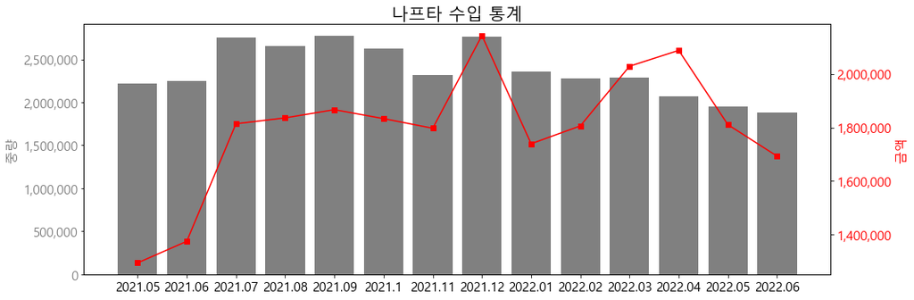

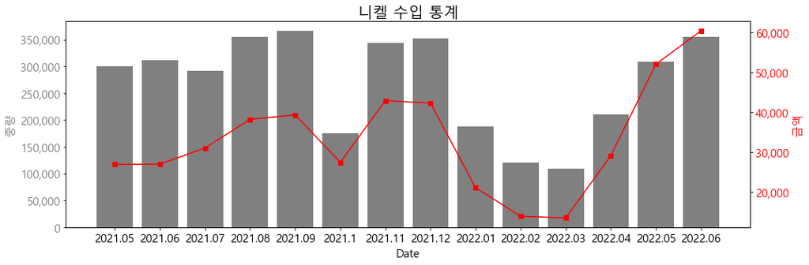

```python
fig, ax1 = plt.subplots(figsize=(15,5), sharex=True)

ax1.set_title('나프타 수입 통계', fontsize=20)
ax1.set_ylabel('중량', fontsize=15, color=color[5])
ax1.bar(naDF.기간, naDF.중량, color=color[5])
ax1.tick_params(axis='y', labelcolor=color[5])
plt.yticks(fontsize=15)
plt.xticks(fontsize=15)
current_values = plt.gca().get_yticks()
plt.gca().set_yticklabels(['{:,.0f}'.format(x) for x in current_values])

ax2 = ax1.twinx()
ax2.set_ylabel('금액', fontsize=15, color='r')
ax2.plot(naDF.기간, naDF.금액, marker='s', color='r')
ax2.tick_params(axis='y', labelcolor='r')
plt.yticks(fontsize=15)

current_values = plt.gca().get_yticks()
plt.gca().set_yticklabels(['{:,.0f}'.format(x) for x in current_values])

fig.tight_layout()

fig, ax1 = plt.subplots(figsize=(15,5))

ax1.set_title('니켈 수입 통계', fontsize=20)
ax1.set_xlabel('Date', fontsize=15)
ax1.set_ylabel('중량', fontsize=15, color=color[5])
ax1.bar(niDF.기간, niDF.중량, color=color[5])
ax1.tick_params(axis='y', labelcolor=color[5])
plt.yticks(fontsize=15)
plt.xticks(fontsize=15)
current_values = plt.gca().get_yticks()
plt.gca().set_yticklabels(['{:,.0f}'.format(x) for x in current_values])

ax2 = ax1.twinx()
ax2.set_ylabel('금액', fontsize=15, color='r')
ax2.plot(niDF.기간, niDF.금액, marker='s', color='r')
ax2.tick_params(axis='y', labelcolor='r')
plt.yticks(fontsize=15)

current_values = plt.gca().get_yticks()
plt.gca().set_yticklabels(['{:,.0f}'.format(x) for x in current_values])


fig.tight_layout()

plt.show()
```

### [광물성원료 데이터 분석 : 니프타, 니켈]

광물성연료의 급등으로 국내 제조업체들의 피해 또한 예측된다. 플라스틱과 섬유 원료로 ‘석유화학의 쌀’로 불리는 나프타 가격이 유가 상승으로 14년여 만에 최고치를 기록한 영향이 컸다. 나프타 가격이 오르면 플라스틱과 의류, 고무 등 소비재 원가도 상승한다. 러시아는 한국의 최대 나프타 수입국이다. 한국의 지난해 수입량 2900만t 중 23%(667만t)를 들여왔다. 투자업계는 석유화학 기업이 원가 상승과 수급 불안이라는 이중고를 겪을 것으로 보고 있다

## * 결론

```
- 러시아 우크라이나 전쟁을 기점으로  품목별 수출물가 대비 수입물가의 급등으로 국내 무역 적자가 지속될 것으로 보인다. 이같은 물가 상승 부담이 국내외 경제 전반을 압박하며 수출 의존도가 높은 우리 경제 구조상 수출입 원자재와 밀접한 관련이 있는 국내 기업의 피해가 지속될 것으로 예상된다. 특히 국내 기억들의 주요 수출품인 반도체나 가전, 휴대폰 등의 수출 모멘텀은 둔화되는 반면 국제 유가의 지속적 상승으로 석유제품 등의 수입가격에 대한 부담은 갈수록 커질 가능성이 높다.
- 유가 등 원자재 가격 상승은 물가 상승을 초래하고 소비비상의 위축으로 인플레이션 우려와 급격한 경기 둔화가 동시에 일어나는 스태그플레이션이 현실화 될 것이 우려된다.
- 원자재 가격상승 리스크에 대한 개별 기업 차원의 대책 수립이 불가능 할 것으로 보이며 경쟁력 회복을 위해 정부의 법인세 감면 등 세제 지원, 수출입 정책 개선 등 실효성 있는 지원책 강화가 필요해보인다.
```